# CSCI 385 - First Deliverable

### thalach: Maximum Heart Rate Achieved

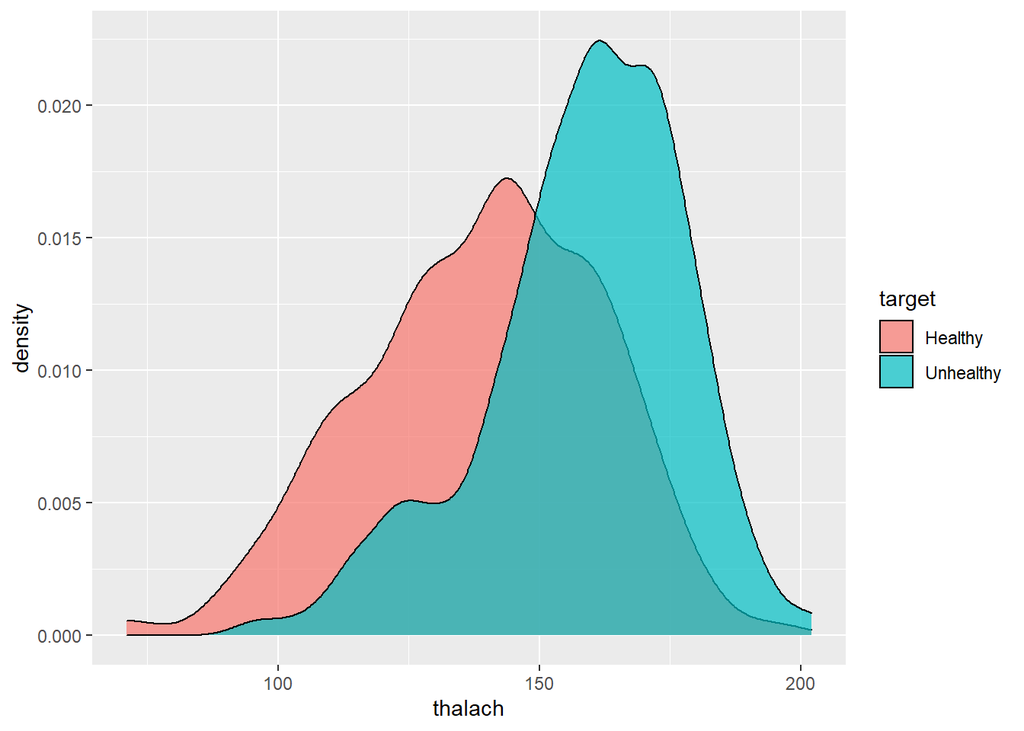

```r
ggplot(aes(thalach, fill=target), data=heart) +
  geom_density(alpha = .7)
```

When looking at the distribution of maximum heart rate achieved by patients with healthy vs unhealthy hearts we can see that patients with unhealthy hearts are more likely to achieve higher maximum heart rates. Unhealthy patients distribution is more left skewed with the majority concentrated on the high end, while healthy patients have a more normal distribution. Maximum heart rate achieved may be a useful factor when predicting heart disease.

### oldpeak: ST depression induced by exercise relative to rest

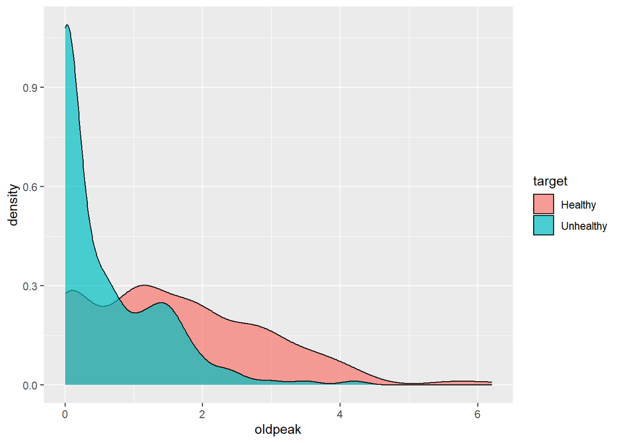

```r
ggplot(aes(oldpeak, fill=target), data=heart) +
  geom_density(alpha = .7)
```

The distribution of oldpeak in healthy vs unhealthy hearts are quite different. Patients with unhealthy hearts distribution appears to be exponential with most patients having an oldpeak of around 0, while healthy patients are more distributed. Oldpeak appears it may prove to be useful when predicting heart disease.